# Analysis of OMICS data, practical 8

Transcriptomics part 2: Differential expression analysis

Eszter Ari

arieszter@ttk.elte.hu

Eötvös Loránd University, Budapest & Biological Research Centre, Szeged

April 10, 2026

## Workflow of RNA-seq data analysis

0. Extract expressed RNA, sequencing → FASTQ file
1. Pre-mapping quality checking, trimming (filtering)
2. Read mapping to reference genome **OR** *de novo* assembly of transcripts
   - Post mapping quality checking
3. Read counting
4. Quantitative or Differential Expression Analyses: comparing expression levels
5. Functional enrichment analysis in GO, pathways, *etc*.

## Normalization

- It is **not possible to do absolute quantification** using the standard RNA-Seq pipeline
  - because it only provides RNA levels *relative* to all transcripts
- The **counts need to be adjusted** to be comparable across samples and experiments
  - because the total coverage (sum of all read counts) differs across samples
  - Relative *vs.* absolute expressions

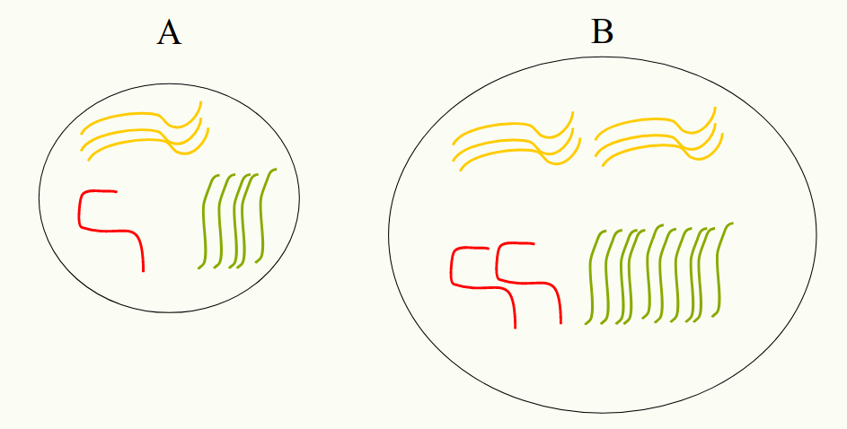

## Sampling reads from a population of mRNA fragments is multinomial

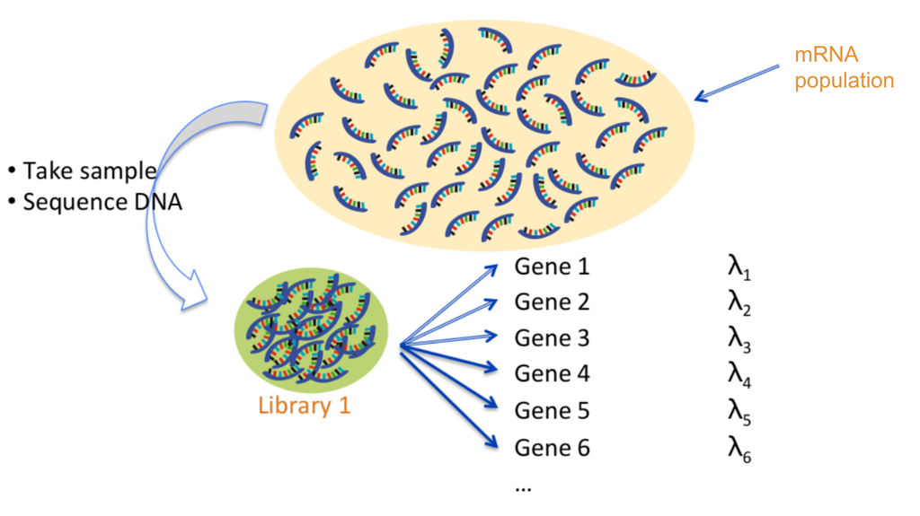

© Mark Robinson

## For a single gene, it is a coin toss, *i.e.,* binomial

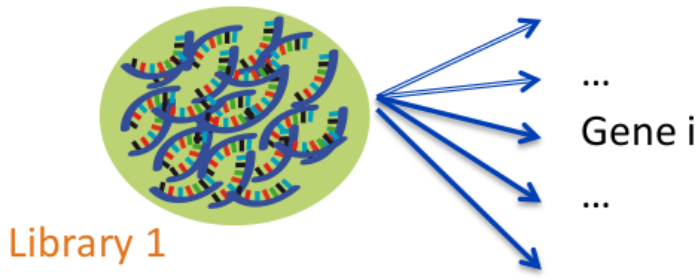

$Y_{i}\sim Binomial\left ( M,\lambda_{i} \right )$

$Y_{i} =$ the observed number of reads for gene $i$

$M =$ the total number of reads (library size)

$\lambda_{i} =$ proportion (relative abundance) of gene $i$ reads (lambda)

Large $M$, small $\lambda_{i}$ → approximated well by Poisson $\left ( \mu _{i} = M\cdot \lambda _{i} \right )$ (mu)

© Mark Robinson

## Technical replication *vs.* biological replication

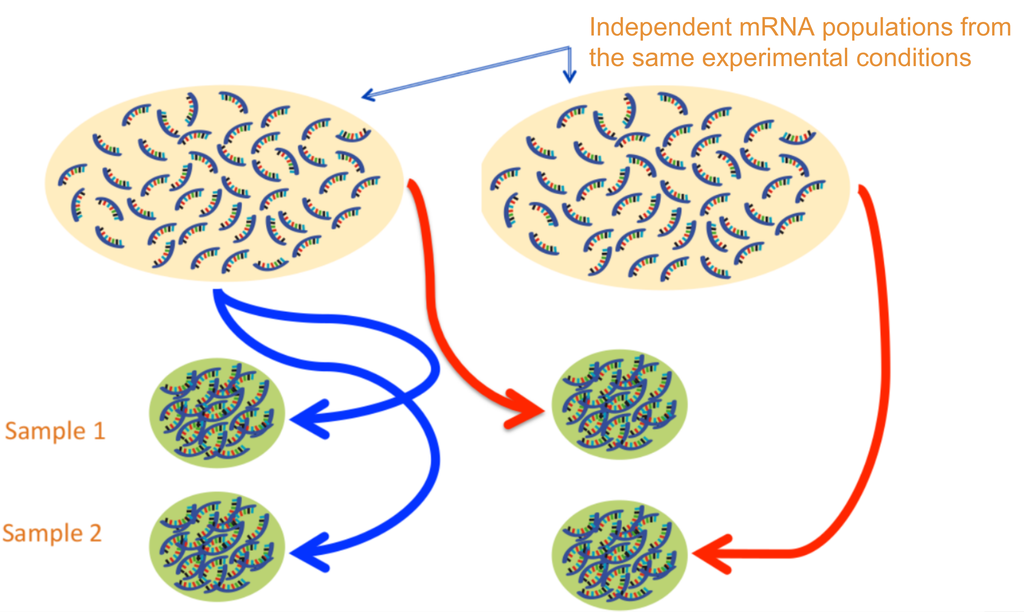

© Mark Robinson

## Technical replication *vs.* biological replication

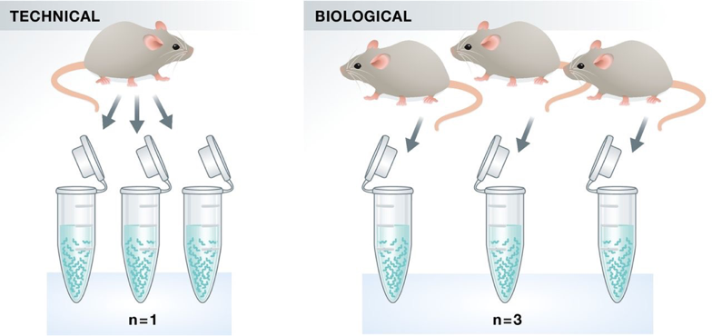

Image credit: Klaus B., *EMBO J* (2015) 34: 2727-2730

## Mean-variance plots

What we see in real data

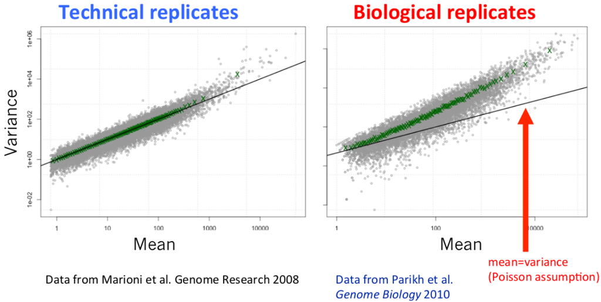

© Mark Robinson

## Model assumptions

$M =$ the total number of reads (library size)

$\lambda_{i} =$ proportion (relative abundance) of gene $i$ reads (lambda)

### Poisson describes technical variation:

$$Y_{i}\sim Poisson\left ( M\cdot \lambda_{i} \right )$$
$$mean\left ( Y_{i} \right ) = variance \left ( Y_{i} \right ) = M\cdot \lambda_{i}$$

### Negative binomial describes biological variation:

$\varphi =$ dispersion parameter (phi)

$$Y_{i}\sim NB\left ( \mu_{i} = M\cdot \lambda_{i}, \varphi_{i} \right )$$
Same mean, but variance is larger (quadratic):

$$variance\left ( Y_{i} \right ) = \mu_{i} \left ( 1 + \mu_{i} \varphi_{i} \right )$$

Critical parameter to estimate: $\varphi_{i} =$ dispersion

© Mark Robinson

## Reasons behind differences in read numbers

- **Library composition** (*i.e.* relative size of the studied transcriptome) can be different in two different biological conditions.
- **Library size** (*i.e.,* sequencing depth) varies between samples coming from different lanes of the flow cell of the sequencing machine.
- **Gene length**: Longer genes will have a higher number of reads.
- **GC content** biases across different genes and samples may lead to a biased sampling.
- Read coverage of a transcript can be biased and **non-uniformly distributed** along the transcript.

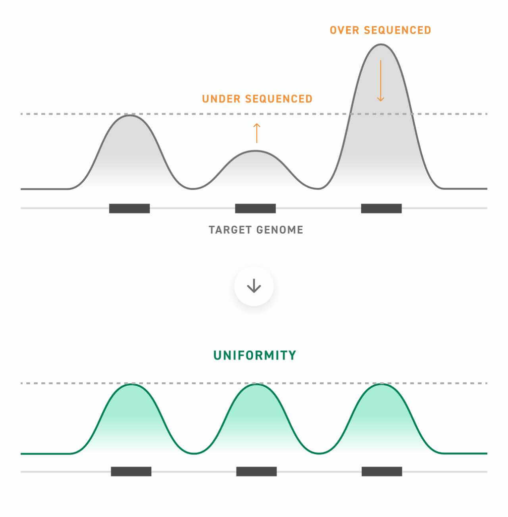

## Basic normalization approaches

Addressing library size biases

- **CPM**: *Counts Per Million*
  - Normalizes the counts by the total number of reads in the library.
  - $CPM = \frac{\text{Nr. of read counts of the gene × } 10^{6}}{\text{Total nr. of counted reads}}$

Addressing library size and gene length biases

- **TPM**: *Transcripts Per Million*
- **RPKM**: *Reads Per Kilobase of transcript per Million mapped reads*
  - Normalizes by the length of the gene also.
  - $RPKM = \frac{\text{Nr. of read counts of the gene × } 10^{3} × 10^{6}}{\text{Total nr. of counted reads × Gene length}}$

## More advanced normalization approaches

- DESeq2’s **median of ratios**:
  - Normalizes the counts by the size factors of the samples.
  - The size factor is calculated from the median of ratios of each gene’s counts to the geometric mean of all genes.
- edgeR’s **TMM**: *Trimmed Mean of M-values*
  - Normalizes samples using a trimmed mean of log-fold changes between samples (*M*) to correct for library size and RNA-composition differences.

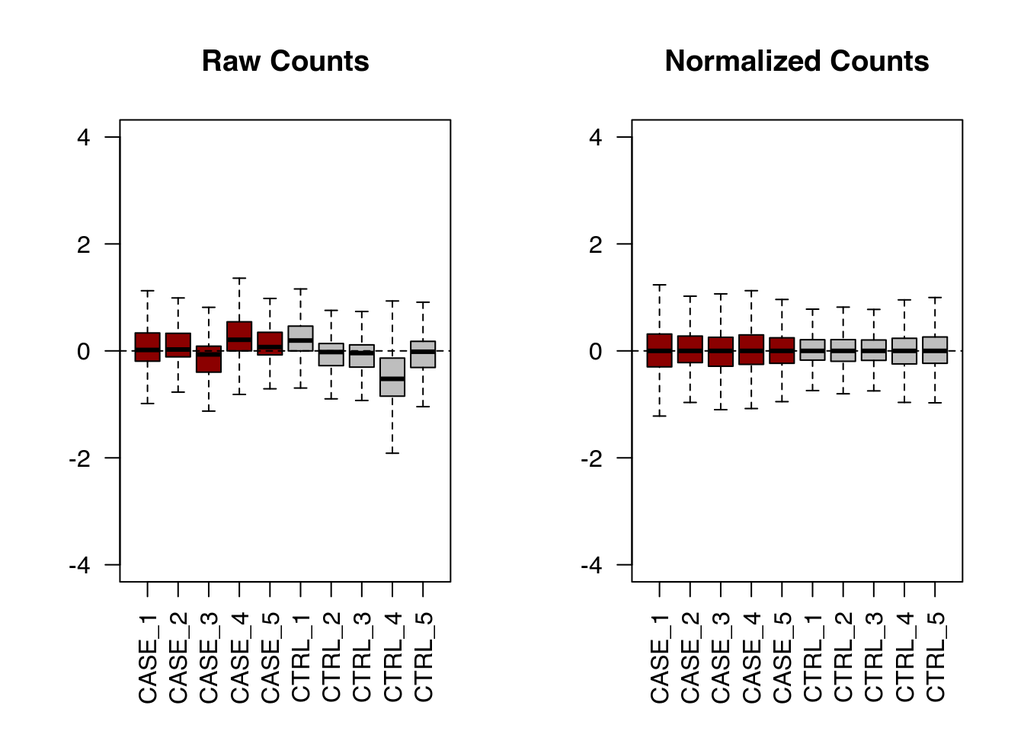

## Experimental layout

**2 groups:**

- Question: Which genes are expressed significantly differently between the two groups? → *p*-value
- The direction and magnitude of the difference → **Fold change**
- **pairwise DE analysis**

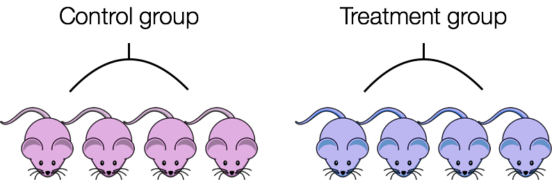

## Experimental layout

**Two or more treatment types, two or more groups:**

- Question: Does a factor (treatment type) cause DE? In which genes?
  - Factors: *e.g.,* obese or not; male or female …
- We use a **Generalized Linear Model (GLM)** to calculate the *p*-value
- The direction of the difference → **Fold change**

# Modelling mean and variance of read counts with LM and GLM

## Generalized Linear Model (GLM)

- **Linear models (LM)** assume a *normal distribution of residuals* and a direct linear relationship,
- while **Generalized Linear Models (GLM)** generalize this by *allowing response variables to have non-normal distributions* (*e.g.*, binary or Poisson) via a “link function.”
- LM is used for continuous, normally distributed data,
- while GLM handles complex data structures.

## Understanding GLM

Using a small simulated RNA-seq dataset of **50 genes** to show

- the **mean-variance relationship** of count data
- why a **linear model** is usually not ideal for raw counts
- how a **Poisson GLM** improves the model for counts
- why **negative binomial GLMs** are usually preferred for RNA-seq because of **overdispersion**

## Simulate RNA-seq counts for 2 conditions, 4-4 replicates, and 50 genes

Count matrix

|  | S1 | S2 | S3 | S4 | S5 | S6 | S7 | S8 |
| --- | --- | --- | --- | --- | --- | --- | --- | --- |
| Gene_01 | 5 | 6 | 6 | 7 | 6 | 3 | 3 | 4 |
| Gene_02 | 9 | 8 | 8 | 4 | 11 | 6 | 7 | 2 |
| Gene_03 | 5 | 12 | 11 | 7 | 4 | 1 | 7 | 7 |
| Gene_04 | 4 | 0 | 8 | 8 | 6 | 9 | 2 | 10 |
| Gene_05 | 1 | 7 | 10 | 6 | 11 | 13 | 6 | 6 |
| Gene_06 | 14 | 9 | 13 | 9 | 14 | 9 | 11 | 9 |
| Gene_07 | 11 | 16 | 14 | 10 | 4 | 13 | 17 | 8 |
| Gene_08 | 12 | 9 | 11 | 11 | 19 | 26 | 31 | 22 |
| Gene_09 | 16 | 18 | 11 | 18 | 15 | 9 | 8 | 18 |
| Gene_10 | 15 | 5 | 13 | 22 | 9 | 25 | 15 | 25 |
| Gene_11 | 23 | 16 | 33 | 14 | 21 | 17 | 26 | 19 |
| Gene_12 | 20 | 26 | 12 | 16 | 33 | 12 | 29 | 15 |
| Gene_13 | 23 | 23 | 23 | 28 | 38 | 25 | 18 | 25 |
| Gene_14 | 44 | 24 | 23 | 29 | 27 | 27 | 15 | 15 |
| Gene_15 | 22 | 43 | 14 | 31 | 18 | 15 | 21 | 13 |
| Gene_16 | 22 | 35 | 33 | 57 | 18 | 32 | 36 | 47 |
| Gene_17 | 31 | 35 | 50 | 39 | 26 | 36 | 37 | 26 |
| Gene_18 | 48 | 49 | 70 | 56 | 36 | 47 | 45 | 24 |
| Gene_19 | 55 | 95 | 39 | 61 | 84 | 60 | 60 | 74 |
| Gene_20 | 71 | 46 | 59 | 115 | 65 | 100 | 74 | 56 |
| Gene_21 | 43 | 126 | 82 | 85 | 57 | 64 | 76 | 44 |
| Gene_22 | 55 | 128 | 78 | 52 | 52 | 37 | 69 | 42 |
| Gene_23 | 125 | 63 | 95 | 59 | 64 | 109 | 108 | 112 |
| Gene_24 | 138 | 95 | 136 | 109 | 386 | 249 | 457 | 168 |
| Gene_25 | 195 | 182 | 83 | 67 | 148 | 150 | 181 | 89 |
| Gene_26 | 141 | 168 | 175 | 101 | 109 | 149 | 190 | 92 |
| Gene_27 | 131 | 174 | 268 | 175 | 93 | 155 | 202 | 221 |
| Gene_28 | 139 | 212 | 197 | 124 | 181 | 86 | 301 | 132 |
| Gene_29 | 97 | 298 | 261 | 124 | 349 | 187 | 354 | 174 |
| Gene_30 | 414 | 185 | 82 | 223 | 198 | 257 | 310 | 227 |
| Gene_31 | 342 | 437 | 136 | 274 | 206 | 130 | 119 | 202 |
| Gene_32 | 271 | 486 | 250 | 335 | 402 | 441 | 374 | 361 |
| Gene_33 | 434 | 577 | 280 | 248 | 300 | 416 | 303 | 412 |
| Gene_34 | 564 | 283 | 400 | 368 | 357 | 566 | 412 | 423 |
| Gene_35 | 475 | 440 | 319 | 268 | 267 | 713 | 440 | 982 |
| Gene_36 | 368 | 518 | 495 | 625 | 368 | 473 | 523 | 527 |
| Gene_37 | 532 | 1038 | 795 | 557 | 574 | 937 | 549 | 467 |
| Gene_38 | 811 | 583 | 694 | 486 | 814 | 753 | 661 | 410 |
| Gene_39 | 988 | 937 | 1312 | 913 | 805 | 1075 | 1069 | 579 |
| Gene_40 | 637 | 1130 | 1452 | 591 | 3790 | 877 | 1170 | 965 |
| Gene_41 | 1186 | 1056 | 1370 | 1098 | 1235 | 999 | 981 | 1755 |
| Gene_42 | 694 | 1273 | 2574 | 2014 | 2729 | 335 | 1101 | 1601 |
| Gene_43 | 1822 | 918 | 290 | 1044 | 1399 | 2305 | 2262 | 704 |
| Gene_44 | 2391 | 1308 | 1161 | 1622 | 3808 | 1694 | 760 | 1034 |
| Gene_45 | 1237 | 1376 | 1334 | 2024 | 1212 | 1687 | 2224 | 2483 |
| Gene_46 | 4011 | 2523 | 2234 | 972 | 1776 | 3203 | 1570 | 1560 |
| Gene_47 | 4900 | 3335 | 2336 | 3948 | 1854 | 1567 | 1839 | 1204 |
| Gene_48 | 4154 | 2719 | 3880 | 4272 | 4143 | 4814 | 6158 | 4527 |
| Gene_49 | 4933 | 3362 | 5728 | 5872 | 3635 | 2747 | 6224 | 4017 |
| Gene_50 | 4601 | 1732 | 1569 | 2709 | 5349 | 4938 | 2731 | 4577 |

## Mean-variance table

| gene | mean_count | variance_count |
| --- | --- | --- |
| Gene_01 | 5.000 | 2.285714e+00 |
| Gene_02 | 6.875 | 8.125000e+00 |
| Gene_03 | 6.750 | 1.278571e+01 |
| Gene_04 | 5.875 | 1.269643e+01 |
| Gene_05 | 7.500 | 1.400000e+01 |
| Gene_06 | 11.000 | 5.428571e+00 |
| Gene_07 | 11.625 | 1.855357e+01 |
| Gene_08 | 17.625 | 6.626786e+01 |
| Gene_09 | 14.125 | 1.755357e+01 |
| Gene_10 | 16.125 | 5.412500e+01 |
| Gene_11 | 21.125 | 3.812500e+01 |
| Gene_12 | 20.375 | 6.483929e+01 |
| Gene_13 | 25.375 | 3.398214e+01 |
| Gene_14 | 25.500 | 8.400000e+01 |
| Gene_15 | 22.125 | 1.046964e+02 |
| Gene_16 | 35.000 | 1.571429e+02 |
| Gene_17 | 35.000 | 6.057143e+01 |
| Gene_18 | 46.875 | 1.812679e+02 |
| Gene_19 | 66.000 | 3.108571e+02 |
| Gene_20 | 73.250 | 5.393571e+02 |
| Gene_21 | 72.125 | 7.306964e+02 |
| Gene_22 | 64.125 | 8.426964e+02 |
| Gene_23 | 91.875 | 6.795536e+02 |
| Gene_24 | 217.250 | 1.841936e+04 |
| Gene_25 | 136.875 | 2.533554e+03 |
| Gene_26 | 140.625 | 1.339125e+03 |
| Gene_27 | 177.375 | 2.929982e+03 |
| Gene_28 | 171.500 | 4.476286e+03 |
| Gene_29 | 230.500 | 9.861429e+03 |
| Gene_30 | 237.000 | 9.372000e+03 |
| Gene_31 | 230.750 | 1.283450e+04 |
| Gene_32 | 365.000 | 6.406286e+03 |
| Gene_33 | 371.250 | 1.188364e+04 |
| Gene_34 | 421.625 | 9.706554e+03 |
| Gene_35 | 488.000 | 6.074857e+04 |
| Gene_36 | 487.125 | 7.354696e+03 |
| Gene_37 | 681.125 | 4.546098e+04 |
| Gene_38 | 651.500 | 2.206429e+04 |
| Gene_39 | 959.750 | 4.595964e+04 |
| Gene_40 | 1326.500 | 1.070970e+06 |
| Gene_41 | 1210.000 | 6.529257e+04 |
| Gene_42 | 1540.125 | 7.347178e+05 |
| Gene_43 | 1343.000 | 5.413911e+05 |
| Gene_44 | 1722.250 | 9.563779e+05 |
| Gene_45 | 1697.125 | 2.405984e+05 |
| Gene_46 | 2231.125 | 9.825321e+05 |
| Gene_47 | 2622.875 | 1.694912e+06 |
| Gene_48 | 4333.375 | 9.259554e+05 |
| Gene_49 | 4564.750 | 1.695151e+06 |
| Gene_50 | 3525.750 | 2.275014e+06 |

## Mean-variance pattern across genes

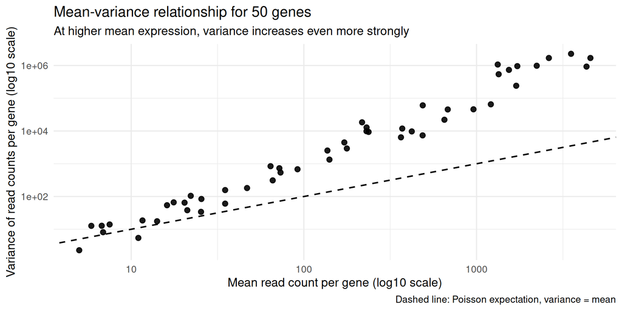

**Interpretation**

- Each point is one gene.
- In a **Poisson** model, variance is expected to be close to the mean.
- Here, genes with larger means tend to have **even larger variances**.
- This is the typical **overdispersed** pattern seen in biological replicate RNA-seq data.
- That is why **negative binomial GLMs** are standard for differential expression.

## Pick one example gene

| gene | sample | count | condition | log_count |
| --- | --- | --- | --- | --- |
| Gene_48 | S1 | 4154 | Control | 12.02063 |
| Gene_48 | S2 | 2719 | Control | 11.40939 |
| Gene_48 | S3 | 3880 | Control | 11.92221 |
| Gene_48 | S4 | 4272 | Control | 12.06103 |
| Gene_48 | S5 | 4143 | Treatment | 12.01681 |
| Gene_48 | S6 | 4814 | Treatment | 12.23332 |
| Gene_48 | S7 | 6158 | Treatment | 12.58848 |
| Gene_48 | S8 | 4527 | Treatment | 12.14466 |

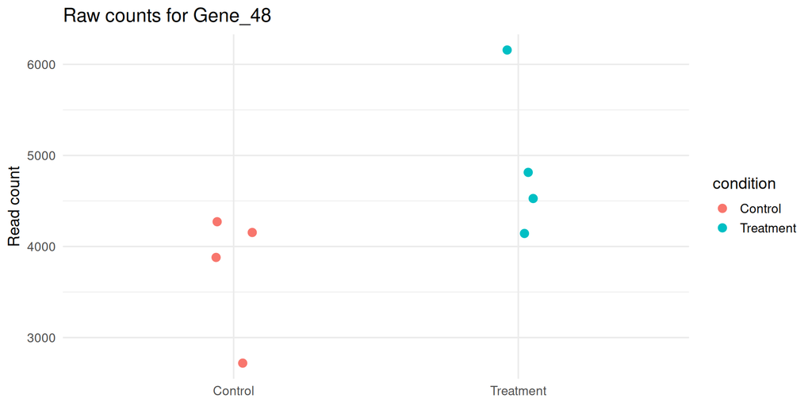

## 1. Linear model (LM)

A linear model is familiar and simple, but RNA-seq counts are not ideal for it because they are:

- integers
- non-negative
- right-skewed
- the variance is not constant across the range of fitted values or predictors

```r
lm_fit <- lm(log_count ~ condition, data = example_dat)
summary(lm_fit)
```

```
Call:
lm(formula = log_count ~ condition, data = example_dat)

Residuals:
    Min      1Q  Median      3Q     Max
-0.4439 -0.1331  0.0282  0.1774  0.3427

Coefficients:
                   Estimate Std. Error t value Pr(>|t|)
(Intercept)         11.8533     0.1374   86.26 1.64e-10 ***
conditionTreatment   0.3925     0.1943    2.02   0.0899 .
---
Signif. codes:  0 '***' 0.001 '**' 0.01 '*' 0.05 '.' 0.1 ' ' 1

Residual standard error: 0.2748 on 6 degrees of freedom
Multiple R-squared:  0.4047,    Adjusted R-squared:  0.3055
F-statistic: 4.079 on 1 and 6 DF,  p-value: 0.08994
```

## 2. Poisson GLM

A Poisson GLM models counts directly with a log link, but it assumes: $\mathrm{Var}(Y) = \mathrm{E}(Y) = μ$

- $Y$: the observed count variable, for example the read count of one gene in one sample
- $\mathrm{Var}(Y)$: the variance of $Y$, meaning how much the counts vary around the mean
- $\mathrm{E}(Y)$: the expected value of $Y$, meaning the average or mean count
- $μ$: a standard symbol for the mean (*mu*)

```r
pois_fit <- glm(count ~ condition,
                family = poisson(link = "log"),
                data = example_dat)
summary(pois_fit)
```

```
Call:
glm(formula = count ~ condition, family = poisson(link = "log"),
    data = example_dat)

Coefficients:
                   Estimate Std. Error z value Pr(>|z|)
(Intercept)        8.231176   0.008158 1008.95   <2e-16 ***
conditionTreatment 0.267955   0.010838   24.72   <2e-16 ***
---
Signif. codes:  0 '***' 0.001 '**' 0.01 '*' 0.05 '.' 0.1 ' ' 1

(Dispersion parameter for poisson family taken to be 1)

    Null deviance: 1498.89  on 7  degrees of freedom
Residual deviance:  882.16  on 6  degrees of freedom
AIC: 967.68

Number of Fisher Scoring iterations: 4
```

## 3. Negative binomial GLM

The negative binomial GLM adds a dispersion term, allowing: $\mathrm{Var}(Y) = μ + ϕ μ^2$

- $Y$: the observed count variable, for example the read count of one gene in one sample
- $\mathrm{Var}(Y)$: the variance of $Y$, meaning how much the counts vary around the mean
- $μ$: the expected value, or mean count (*mu*)
- $μ^2$: the square of the mean
- $ϕ$: the dispersion parameter, which allows the variance to be larger than the mean (*phi*)

```r
nb_fit <- MASS::glm.nb(count ~ condition, data = example_dat)
summary(nb_fit)
```

```
Call:
glm.nb(formula = count ~ condition, data = example_dat, init.theta = 38.21519995,
    link = log)

Coefficients:
                   Estimate Std. Error z value Pr(>|z|)
(Intercept)         8.23118    0.08129 101.254   <2e-16 ***
conditionTreatment  0.26795    0.11490   2.332   0.0197 *
---
Signif. codes:  0 '***' 0.001 '**' 0.01 '*' 0.05 '.' 0.1 ' ' 1

(Dispersion parameter for Negative Binomial(38.2152) family taken to be 1)

    Null deviance: 13.461  on 7  degrees of freedom
Residual deviance:  8.038  on 6  degrees of freedom
AIC: 133.33

Number of Fisher Scoring iterations: 1

              Theta:  38.2
          Std. Err.:  19.2

 2 x log-likelihood:  -127.334
```

## Compare fitted values

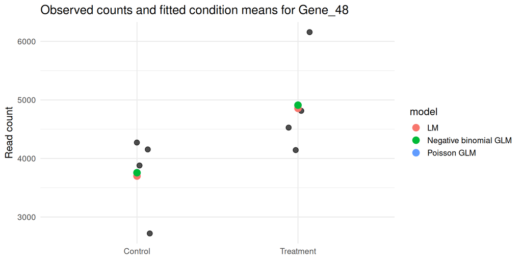

## Poisson *vs.* negative binomial

The fitted means can be the same but the uncertainty intervals around the fitted means are still different.

The uncertainty intervals values of the **Poisson** GLM fitting:

```
          1           2           3           4           5           6
0.008158170 0.008158170 0.008158170 0.008158170 0.007135216 0.007135216
          7           8
0.007135216 0.007135216
```

The uncertainty intervals values of the **Negative binomial** GML fitting:

```
         1          2          3          4          5          6          7
0.08129241 0.08129241 0.08129241 0.08129241 0.08119613 0.08119613 0.08119613
         8
0.08119613
```

# GLM with 2 factors, multiplicative model

model:

$gender × obesity\ status =$

$gender + obesity\ status + gender:obesity\ stauts$

## Gene example 1

Where the **factor gender** explains the differential expression.

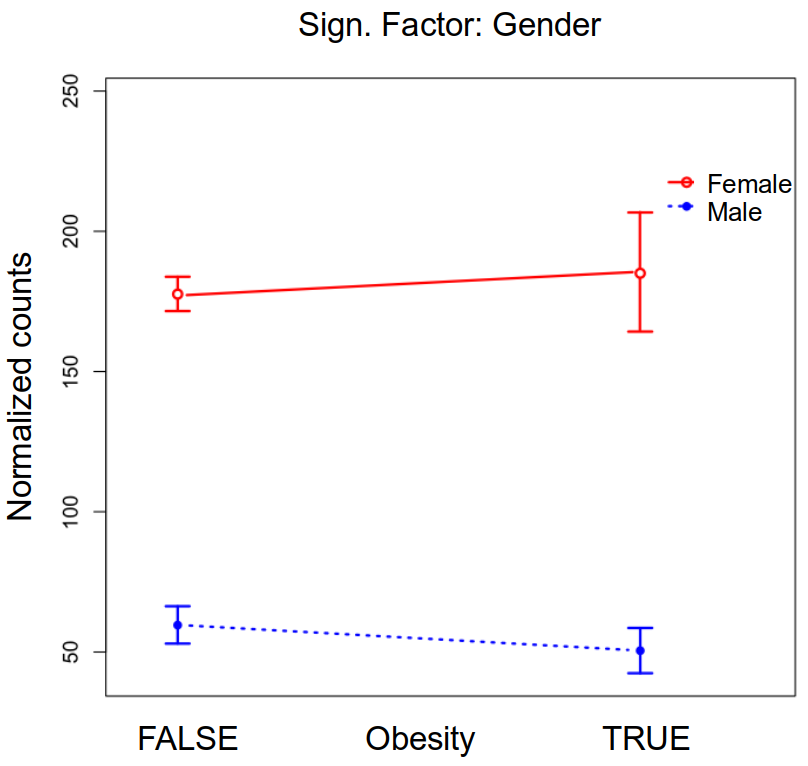

## Gene example 2

Where the **factor obesity status** explains the differential expression.

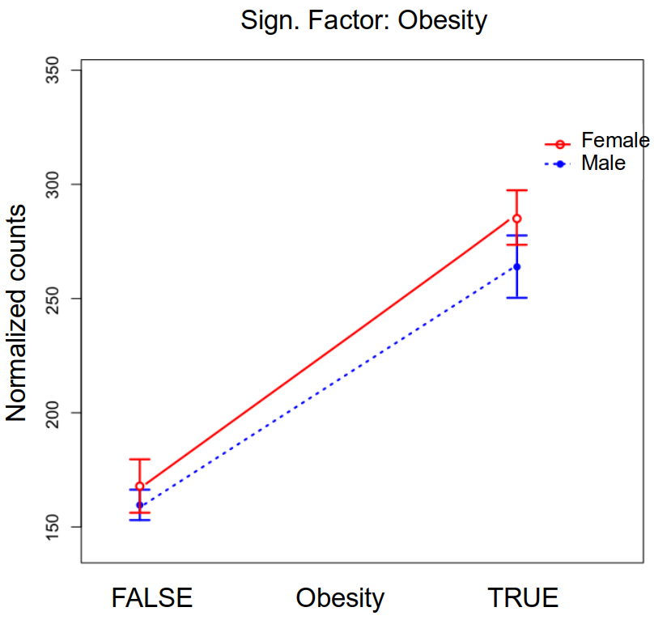

## Gene example 3

Where the **interaction of the two factors** explains the differential expression.

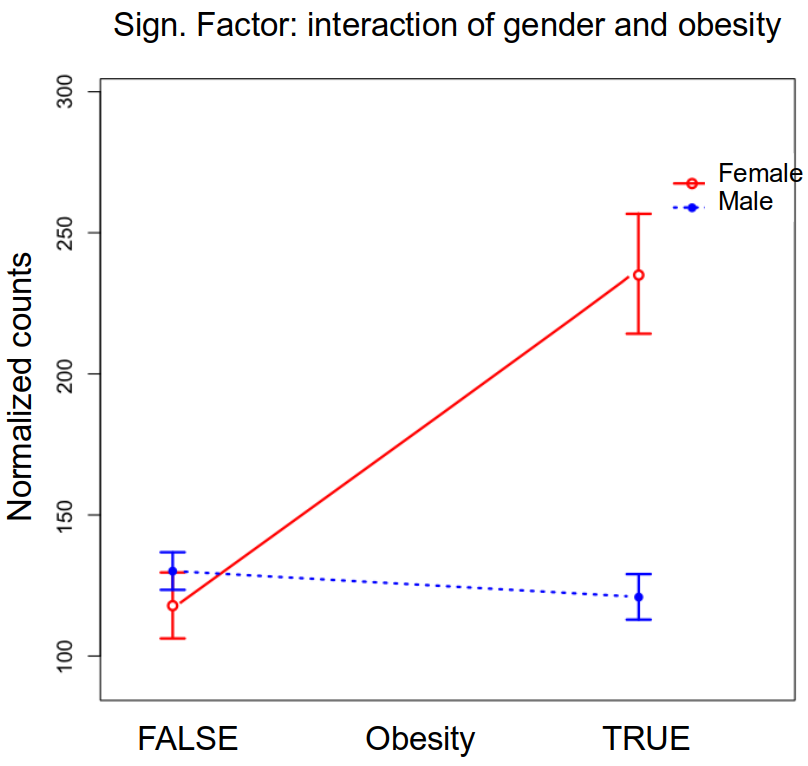

# Visualization of DE results

## MA plot

Transforming the data onto $M$ (log ratio) and $A$ (mean average) scales

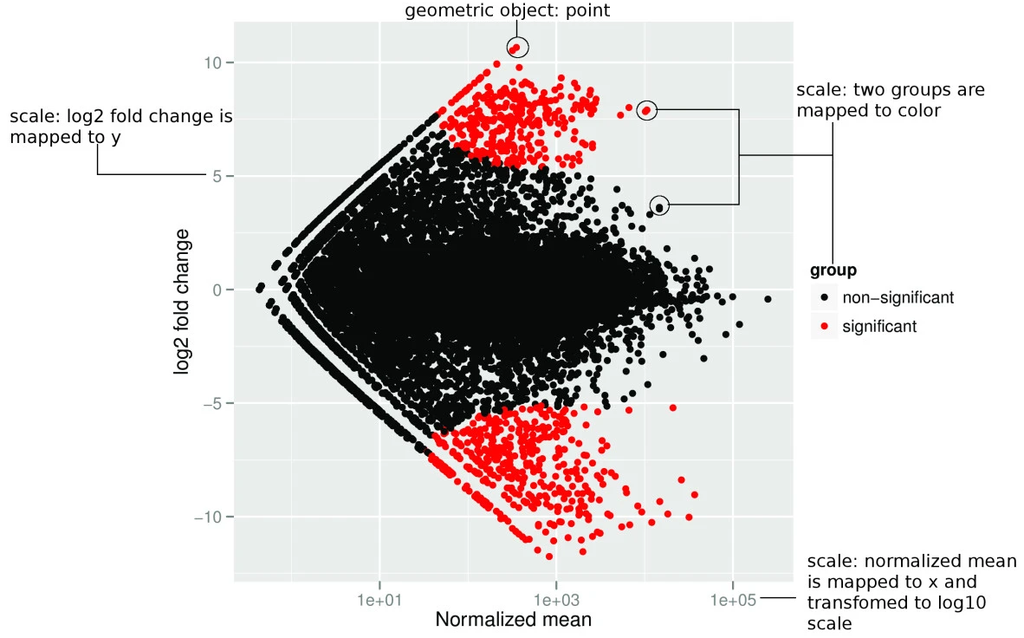

Image credit: Yin T, *et al.*, *Genome Biology* (2012) 13: R77

## Volcano plot

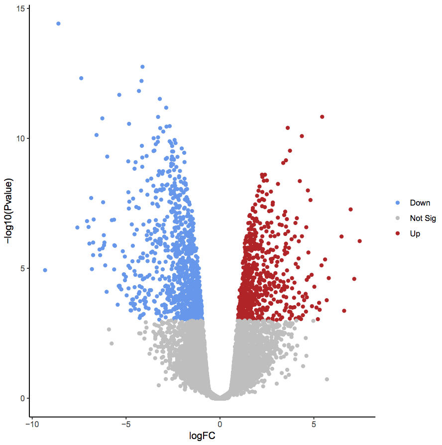

## Multiple testing correction

- We calculate the same statistical test *several times* → all genes we investigated
- If we use $p = 0.05$ as a threshold: we have a $5\%$ chance to accept something significantly differently expressed when the expressions were not different.
- → **False discovery rate (FDR) correction** based on all *p*-values, *i.e.* *Bonferroni* or *Benjamini-Hochberg* correction